# Day 19: K-means — In-Class Activity (Solutions)

Which colleges are like the Claremont Colleges?

Instructor

```r
data(College)
colleges <- College %>%
  mutate(college = rownames(College),          # the names are row names; make them a column
         accept_rate = Accept / Apps) %>%      # share of applicants admitted
  select(college, Private, accept_rate, Top10perc, F.Undergrad, Outstate,
         S.F.Ratio, perc.alumni, Expend, Grad.Rate)

claremont <- c("Claremont McKenna College", "Harvey Mudd College",
               "Pitzer College", "Scripps College")

# The eight columns k-means gets to see (no names, no Private)
X <- colleges %>% select(-college, -Private)
```

### A first look at the data

```r
colleges %>% filter(college %in% claremont)
```

```
##                                             college Private accept_rate
## Claremont McKenna College Claremont McKenna College     Yes   0.4123656
## Harvey Mudd College             Harvey Mudd College     Yes   0.4153958
## Pitzer College                       Pitzer College     Yes   0.5560459
## Scripps College                     Scripps College     Yes   0.7391813
##                           Top10perc F.Undergrad Outstate S.F.Ratio perc.alumni
## Claremont McKenna College        71         887    17000       9.6          52
## Harvey Mudd College              95         654    17230       8.2          46
## Pitzer College                   37         750    17688      10.4          11
## Scripps College                  60         569    17238       8.2          41
##                           Expend Grad.Rate
## Claremont McKenna College  18443        87
## Harvey Mudd College        21569       100
## Pitzer College             14820        73
## Scripps College            18372        73
```

```r
X %>% summarise(across(everything(), sd))     # the SD of each column
```

```
##   accept_rate Top10perc F.Undergrad Outstate S.F.Ratio perc.alumni   Expend
## 1   0.1471039  17.64036    4850.421 4023.016  3.958349     12.3918 5221.768
##   Grad.Rate
## 1  17.17771
```

`Expend` has the largest SD (about $5,200), with `F.Undergrad` (4,850 students) and `Outstate` ($4,000) close behind. `accept_rate` has the smallest (0.15, because it’s a share between 0 and 1), then `S.F.Ratio` (4). On the slides’ shoppers, age had the small SD, and k-means ignored it: it only split on income.

## Part 1: K-means on the Raw Columns

**Prediction:** the three columns with SDs in the thousands, `Expend`, `F.Undergrad`, and `Outstate`.

```r
set.seed(19)
km_raw <- kmeans(X, centers = 3, nstart = 20)
colleges <- colleges %>% mutate(raw = factor(km_raw$cluster))

colleges %>%
  group_by(raw) %>%
  summarise(colleges = n(), across(accept_rate:Grad.Rate, mean))   # the average of each column
```

```
## # A tibble: 3 × 10
##   raw   colleges accept_rate Top10perc F.Undergrad Outstate S.F.Ratio
##   <fct>    <int>       <dbl>     <dbl>       <dbl>    <dbl>     <dbl>
## 1 1          553       0.777      22.0       2039.    9413.      14.5
## 2 2           96       0.724      29.5      14519.    7620.      16.9
## 3 3          128       0.634      50.0       2760.   16998.      10.1
## # ℹ 3 more variables: perc.alumni <dbl>, Expend <dbl>, Grad.Rate <dbl>
```

```r
set.seed(19)
km_three <- kmeans(X %>% select(F.Undergrad, Outstate, Expend), centers = 3, nstart = 20)
table(eight_columns = km_raw$cluster, three_columns = km_three$cluster)
```

```
##              three_columns
## eight_columns   1   2   3
##             1 553   0   0
##             2   0  96   0
##             3   0   0 128
```

The raw clusters are about **size and money**:

- **Big schools** (96 colleges): about 14,519 full-time undergraduates on average, vs 2,039 and 2,760 in the other two.
- **Expensive, high-spending schools** (128): tuition about $17,000 and spending about $18,000 per student, roughly twice the others.
- **Everyone else** (553): smaller and cheaper.

With only three columns, **0 colleges change cluster**: every college lands with exactly the same group as before. So the other five columns (acceptance rate, top-10% share, student-faculty ratio, alumni giving, graduation rate) did nothing. Their SDs are tiny next to thousands of dollars or students, so they barely change any distance, and k-means used only `F.Undergrad`, `Outstate`, and `Expend`. The prediction was right.

## Part 2: Standardize First

```r
set.seed(19)
km_std <- kmeans(scale(X), centers = 3, nstart = 20)
colleges <- colleges %>% mutate(std = factor(km_std$cluster))

colleges %>%
  group_by(std) %>%
  summarise(colleges = n(), across(accept_rate:Grad.Rate, mean),
            share_private = mean(Private == "Yes"))   # Private wasn't used!
```

```
## # A tibble: 3 × 11
##   std   colleges accept_rate Top10perc F.Undergrad Outstate S.F.Ratio
##   <fct>    <int>       <dbl>     <dbl>       <dbl>    <dbl>     <dbl>
## 1 1          384       0.795      26.3       1580.   11596.     12.7
## 2 2           88       0.537      61.6       4032.   17274.      9.70
## 3 3          305       0.747      19.3       6273.    7014.     17.1
## # ℹ 4 more variables: perc.alumni <dbl>, Expend <dbl>, Grad.Rate <dbl>,
## #   share_private <dbl>
```

```r
colleges %>% filter(college %in% claremont) %>% select(college, raw, std)
```

```
##                                             college raw std
## Claremont McKenna College Claremont McKenna College   3   2
## Harvey Mudd College             Harvey Mudd College   3   2
## Pitzer College                       Pitzer College   3   2
## Scripps College                     Scripps College   3   2
```

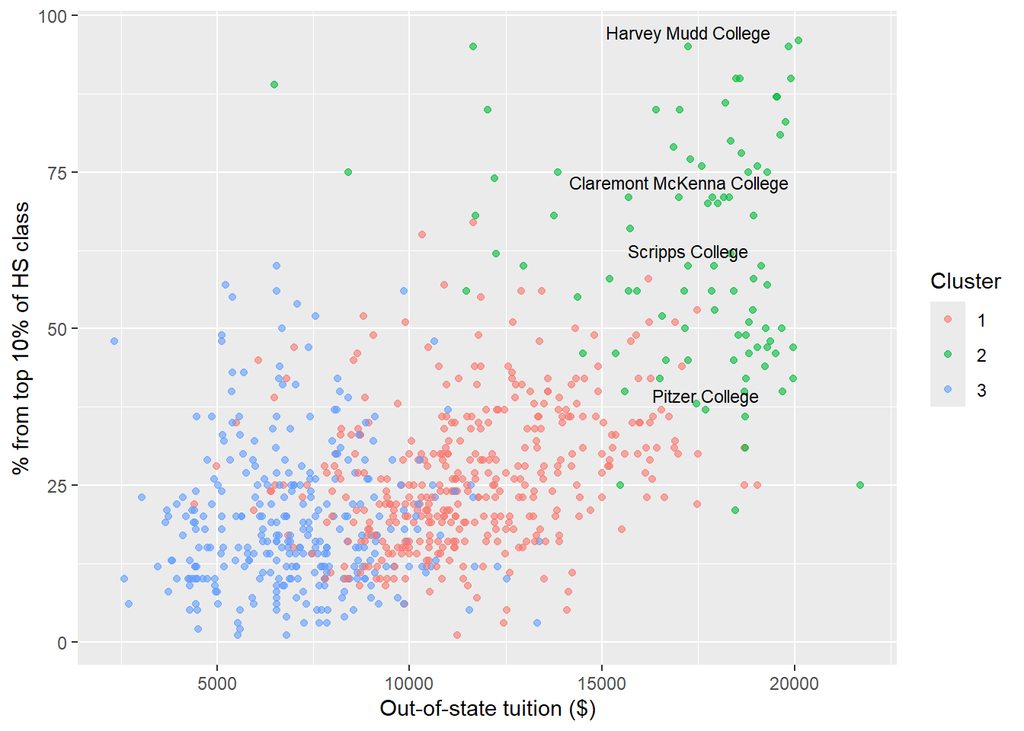

```r
ggplot(colleges, aes(Outstate, Top10perc, color = std)) +
  geom_point(alpha = 0.6) +
  geom_text(data = filter(colleges, college %in% claremont),
            aes(label = college), color = "black", size = 3, vjust = -0.6) +
  labs(x = "Out-of-state tuition ($)", y = "% from top 10% of HS class",
       color = "Cluster")
```

One set of names:

- **Elite colleges** (88): admit 54% of applicants, 62% of students from the top 10% of their class, graduate 85%, tuition $17,300.
- **Small private colleges** (384): about 1,580 undergraduates, admit 79%, tuition $11,600.
- **Large, low-tuition colleges** (305): the biggest (6,273 undergraduates on average), tuition $7,000, more students per faculty member, graduate 54%.

All four Claremont Colleges are in the **elite** cluster (they were also together in the raw “expensive” cluster).

K-means never saw `Private`, but the clusters line up with it well: 98% of the small-private cluster and 92% of the elite cluster are private, and the large, low-tuition cluster holds 196 of the 212 public colleges. It isn’t perfect: only 64% of that cluster is public; the other 36% are cheaper, larger private colleges that look like public ones on these eight columns.

The standardized clusters are more sensible: every column now counts, so the clusters separate on selectivity, size, and cost together, not just on the three columns with big numbers. (The raw “expensive” cluster also looked elite, but only because tuition and spending go along with selectivity; k-means never used the selectivity columns.)

## Part 3: How Many Clusters?

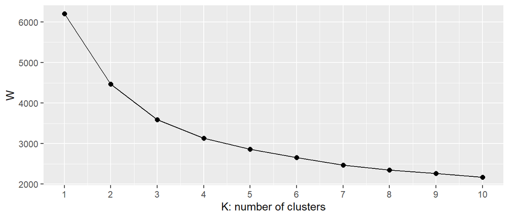

```r
W <- rep(NA, 10)
for (k in 1:10) {
  set.seed(19)
  W[k] <- kmeans(scale(X), centers = k, nstart = 20)$tot.withinss
}

tibble(K = 1:10, W = W) %>%
  ggplot(aes(K, W)) +
  geom_line() +
  geom_point(size = 2) +
  scale_x_continuous(breaks = 1:10) +
  labs(x = "K: number of clusters", y = "W")
```

W falls from 6,208 (K = 1) to 4,468 (K = 2), 3,593 (K = 3) and 3,136 (K = 4), then by less and less (2,856, 2,651, …). There is no sharp elbow like on the slides: the curve bends gradually around K = 3 or 4. Real data rarely come in clean, separate groups. Either 3 or 4 is a reasonable answer; what matters is the reason, e.g. 3 because the drops get much smaller after it, or 4 because the drop from 3 to 4 (457) is still sizable and the fourth cluster is easy to describe.

## Part 4: Who Are Claremont McKenna’s Peers?

```r
set.seed(19)
km4 <- kmeans(scale(X), centers = 4, nstart = 20)
colleges <- colleges %>% mutate(k4 = factor(km4$cluster))

colleges %>% filter(college %in% claremont) %>% select(college, std, k4)
```

```
##                                             college std k4
## Claremont McKenna College Claremont McKenna College   2  4
## Harvey Mudd College             Harvey Mudd College   2  4
## Pitzer College                       Pitzer College   2  1
## Scripps College                     Scripps College   2  4
```

```r
colleges %>%
  group_by(k4) %>%
  summarise(colleges = n(), across(accept_rate:Grad.Rate, mean))
```

```
## # A tibble: 4 × 10
##   k4    colleges accept_rate Top10perc F.Undergrad Outstate S.F.Ratio
##   <fct>    <int>       <dbl>     <dbl>       <dbl>    <dbl>     <dbl>
## 1 1          353       0.791      27.9       1641.   11977.     12.6
## 2 2          275       0.766      16.2       3076.    7242.     16.6
## 3 3           78       0.704      33.2      15521.    8110.     16.6
## 4 4           71       0.504      63.7       3370.   17755.      9.29
## # ℹ 3 more variables: perc.alumni <dbl>, Expend <dbl>, Grad.Rate <dbl>
```

```r
cmc_cluster <- colleges$k4[colleges$college == "Claremont McKenna College"]
colleges %>%
  filter(k4 == cmc_cluster) %>%
  arrange(desc(Top10perc)) %>%
  select(college, Top10perc, Outstate, perc.alumni) %>%
  head(15)
```

```
##                                                                     college
## Massachusetts Institute of Technology Massachusetts Institute of Technology
## Harvey Mudd College                                     Harvey Mudd College
## Yale University                                             Yale University
## Duke University                                             Duke University
## Harvard University                                       Harvard University
## Princeton University                                   Princeton University
## Brown University                                           Brown University
## Dartmouth College                                         Dartmouth College
## Pepperdine University                                 Pepperdine University
## Northwestern University                             Northwestern University
## University of Pennsylvania                       University of Pennsylvania
## Amherst College                                             Amherst College
## Williams College                                           Williams College
## Wellesley College                                         Wellesley College
## University of Notre Dame                           University of Notre Dame
##                                       Top10perc Outstate perc.alumni
## Massachusetts Institute of Technology        96    20100          35
## Harvey Mudd College                          95    17230          46
## Yale University                              95    19840          49
## Duke University                              90    18590          44
## Harvard University                           90    18485          52
## Princeton University                         90    19900          54
## Brown University                             87    19528          39
## Dartmouth College                            87    19545          49
## Pepperdine University                        86    18200          13
## Northwestern University                      85    16404          25
## University of Pennsylvania                   85    17020          38
## Amherst College                              83    19760          63
## Williams College                             81    19629          64
## Wellesley College                            80    18345          51
## University of Notre Dame                     79    16850          46
```

**Pitzer College** moved; CMC, Harvey Mudd and Scripps stay together in a cluster of 71. The column where Pitzer differs most from that cluster is **alumni giving**: 11% of Pitzer’s alumni donate, vs 40% on average in CMC’s cluster (Pitzer’s SD-scale gap there is the biggest of its eight columns). Its top-10% share (37% vs 64%) and spending ($14,800 vs $20,800) are lower too.

Whether Pitzer is a peer depends on what “peer” is for. On cost, size, and student-faculty ratio it is very much like CMC; on alumni giving it isn’t. K-means weighs all eight columns equally, and it doesn’t know that alumni giving might matter less than selectivity for picking peers.

The 15 listed peers are what you’d expect from a highly selective cluster: MIT, Yale, Harvard, Princeton, Duke, Brown, Dartmouth, and liberal arts colleges like Amherst, Williams and Wellesley. Some are big research universities that differ from CMC in size; k-means puts them together because size is only one of the eight columns. Pepperdine is a surprise: its alumni giving is only 13%, like Pitzer’s, but its top-10% share (86%) is high enough to keep it in.

## Bonus

### Bonus 1: Change the units

```r
X_thousands <- X %>% mutate(F.Undergrad = F.Undergrad / 1000)

set.seed(19)
raw_thousands <- kmeans(X_thousands, centers = 3, nstart = 20)
table(students = km_raw$cluster, thousands = raw_thousands$cluster)
```

```
##         thousands
## students   1   2   3
##        1 442   0 111
##        2  85   0  11
##        3   0  26 102
```

```r
set.seed(19)
std_thousands <- kmeans(scale(X_thousands), centers = 3, nstart = 20)
table(students = km_std$cluster, thousands = std_thousands$cluster)
```

```
##         thousands
## students   1   2   3
##        1 384   0   0
##        2   0  88   0
##        3   0   0 305
```

The **raw** clusters change a lot: in thousands, `F.Undergrad` has an SD of about 4.9, so k-means stops seeing it. The big-schools cluster disappears (its colleges are spread over the new clusters, which now split on tuition and spending). The **standardized** clusters don’t change at all (0 colleges move): `scale()` divides each column by its SD, so a column in thousands ends up exactly the same as the column in students. Standardizing makes k-means ignore the units.

### Bonus 2: Choose your own columns

```r
set.seed(19)
km_sel <- kmeans(scale(X %>% select(accept_rate, Top10perc, Grad.Rate)),
                 centers = 4, nstart = 20)
colleges <- colleges %>% mutate(sel = factor(km_sel$cluster))

colleges %>% filter(college %in% claremont) %>% select(college, sel)
```

```
##                                             college sel
## Claremont McKenna College Claremont McKenna College   2
## Harvey Mudd College             Harvey Mudd College   2
## Pitzer College                       Pitzer College   1
## Scripps College                     Scripps College   3
```

```r
colleges %>%
  group_by(sel) %>%
  summarise(colleges = n(), across(c(accept_rate, Top10perc, Grad.Rate), mean))
```

```
## # A tibble: 4 × 5
##   sel   colleges accept_rate Top10perc Grad.Rate
##   <fct>    <int>       <dbl>     <dbl>     <dbl>
## 1 1          135       0.614      21.1      54.3
## 2 2           74       0.473      65.7      87.9
## 3 3          330       0.788      29.7      75.9
## 4 4          238       0.850      16.4      50.4
```

No. On selectivity alone the Claremont Colleges split into **3 clusters**: CMC and Harvey Mudd stay in the most selective one, Pitzer (top-10% share 37%) and Scripps (admits 74% of applicants) end up elsewhere. Scripps moves too, even though it stayed with CMC in Part 4. Change the columns and the “similar” colleges change. K-means doesn’t decide what similar means: **we do**, when we choose the columns (and how to scale them).

### Bonus 3: No CV error

Some ideas:

- Check the clusters against columns k-means **didn’t** see: `Private` (as in Part 2), or others in `College` such as `PhD` (% of faculty with PhDs), `Room.Board`, or `Apps`. If the clusters also differ on those, they capture something real.
- Check that they are **stable**: other seeds, a random half of the colleges, or K = 3 vs 4 should give mostly the same peers.
- Ask whether they are **useful**: does the list of CMC’s peers look like the colleges the dean actually competes with for students? Someone who knows the colleges has to judge that; no number can.